# TP_SVM

SHAO Nuoya, BONNET Clément

2020/10/7

# Exercice I. Introduction aux C-SVM

## Question 1

La formulation duale du problème d’optimisation associé aux SVM s’écrit
$$\begin{split}
max_{\mu \in {\rm I\!R}^n} & \Big\{ \mu^T1 - \frac{1}{2}\mu^T diag(y)Kdiag(y) \mu \Big\} \\
s.t. & \begin{cases}
\mu \in [0;C]^n\\
\mu^Ty = 0
\end{cases}
\end{split}$$

## Question 2

D’après l’aide, on constate qu’il y a 12 arguments à la fonction $\texttt{ipop}$.

$\textbf{c}$ : Vecteur apparaissant dans la fonction quadratique. Ici, $c = -1$.

$\textbf{H}$ : Matrice carrée apparaissant dans la fonction quadratique. Ici $H = diag(y)Kdiag(y)$.

$\textbf{A}$ : Matrice définissant les contraintes sous lesquelles nous minimisons la fonction quadratique. Ici, $A = y^T$.

$\textbf{b}$ : Vecteur définissant les contraintes. Ici, $b = 0$.

$\textbf{l}$ : Vecteur de la borne inférieure. Ici, $l = 0$.

$\textbf{u}$ : Vecteur de la borne supérieure. Ici, $u = C$.

$\textbf{r}$ : Vecteur définissant des contraintes. Ici, $r = 0$.

## Question 3

```r
C = 100
X = matrix(c(1,2,4,5,6),5,1)
y = c(1, 1, -1, -1, 1)
poly = polydot(degree = 2, scale = 1, offset = 1)
K = kernelMatrix(poly, X)
m = nrow(X)

c = rep(-1, m)
H = diag(y) %*% K %*% diag(y)
A = t(y)
b = 0
l = rep(0, m)
u = rep(C, m)
r = 0
sv = ipop(c, H, A, b, l, u, r)
alpha = primal(sv)
alpha
```

```
## [1] 1.277054e-08 2.500000e+00 8.576981e-08 7.333333e+00 4.833333e+00
```

On obtient bien :
$$\alpha_{1} = 0,\ \alpha_{2} = 2.5,\ \alpha_{3} = 0,\ \alpha_{4} = 7.333,\ \alpha_{5} = 4.833$$

## Question 4

D’après le théorème de représentation, on sait que f peut s’écrire sous la forme
$$f = \sum_{i=1}^{n}\alpha_iy_i\kappa(x_i,.) +b$$
où $\kappa$ est la fonction au noyau ici on a choisi le noyau polynomial d’ordre 2 défini comme suit :
$$\kappa(x_1, x_2) = (x_1^Tx_2+1)^2$$
Ainsi,
$$\begin{aligned}
f(x)
&= \alpha_1\kappa(1, x) + \alpha_2\kappa(2, x) - \alpha_3\kappa(4, x) - \alpha_4\kappa(5, x) + \alpha_5\kappa(6, x) + b \\
&= \alpha_1(x+1)^2 + \alpha_2(2x+1)^2 - \alpha_3(4x+1)^2 - \alpha_4(5x+1)^2 + \alpha_5(6x+1)^2 + b \\
&= \omega_2x^2 + \omega_1x + \omega_0
\end{aligned}$$
En utilisant le fait que 2 est un vecteur de support, $f(2) = 1$ et donc on trouve les valeurs de $\omega_i$ suivantes :
$$\begin{align*}
\omega_2 &= \alpha_1 + 4\alpha_2 - 16\alpha_3 - 25\alpha_4 + 36\alpha_5 \\
\omega_1 &= 2\alpha_1 + 4\alpha_2 - 8\alpha_3 - 10\alpha_4 + 12\alpha_5 \\
\omega_0 &= -8\alpha_1 - 24\alpha_2 + 80\alpha_3 + 120\alpha_4 - 168\alpha_5 + 1 \\
\end{align*}$$

On a finalement
$$\omega_2 = 0.667,\ \omega_1 = -5.333,\ \omega_0 = 9$$

## Question 5

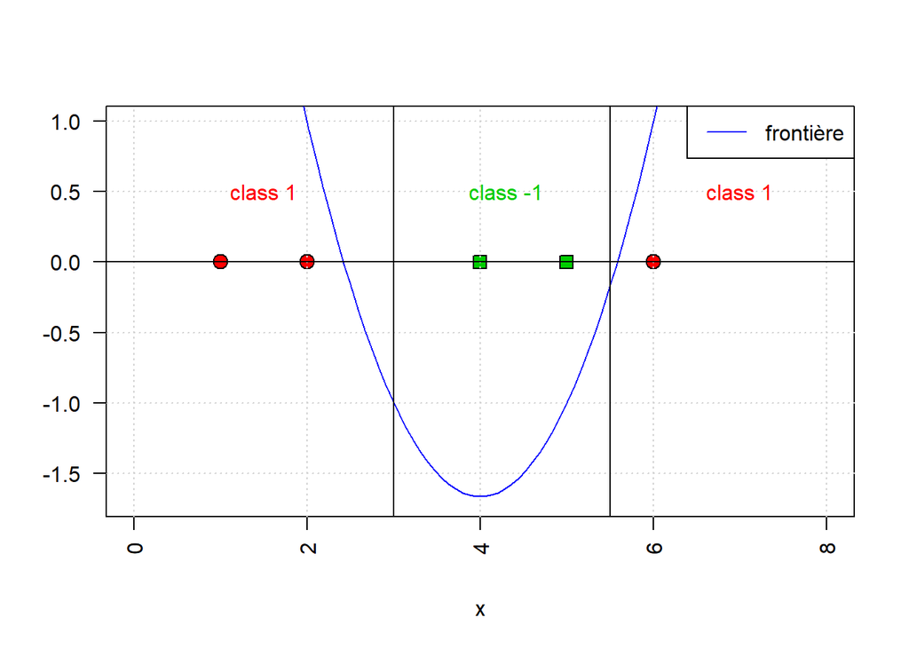

```r
x = c(1, 2, 4, 5, 6)
y = c(1, 1, 2, 2, 1)
w2 = omegas[3]
w1 = omegas[2]
w0 = omegas[1]
xf = seq(0,8,l=100)
f = function(xf){w2*xf^2 + w1*xf + w0}
plot(x, rep(0, 5), pch = c(21, 22)[y], bg = c("red", "green3")[y],
  cex = 1.5, ylim = c(-1.7, 1), xlim = c(0, 8), ylab = "",
  xlab = "x", las = 2)
grid()
lines(xf, f(xf), type='l', col="blue")
legend('topright', legend = c('frontière'), col = c('blue'), lty=1:2)
text(matrix(c(1.5, 4.3, 7, 0.5, 0.5, 0.5), 3, 2),
c("class 1", "class -1", "class 1"),
col = c("red", "green3", "red"))
abline(h=0) ; abline(v=c(3, 5.5))
```

On voit que la fonction f sépare correctement les points de classes différentes.

# Exercice II : Support Vector Machines et validation croisée

## Question 1

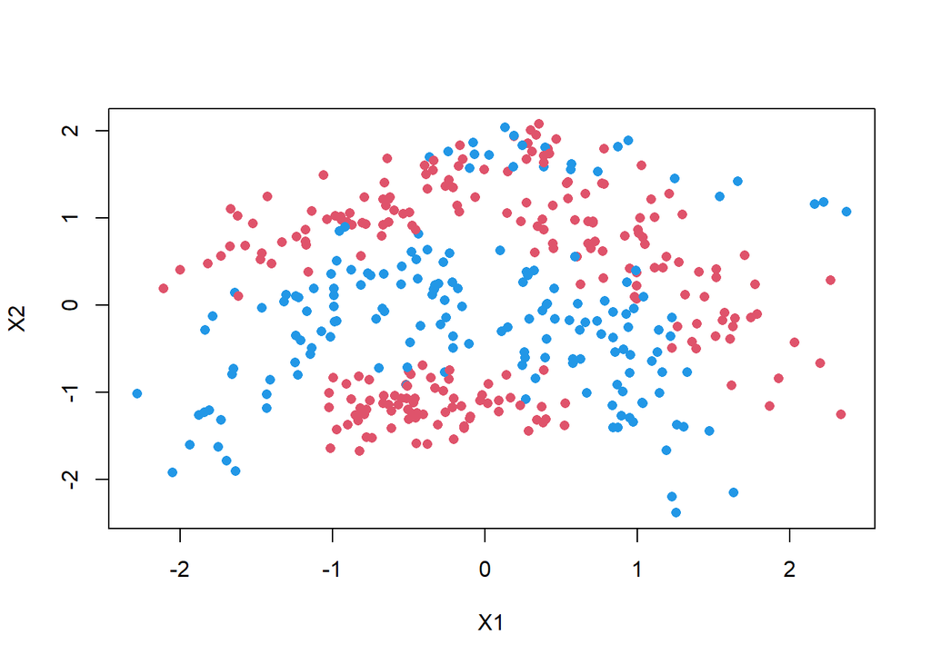

## Question 2

```r
poly1 = rbfdot(sigma = 5)
x1 = as.matrix(cbind(data[,'X1'],data['X2']))
y1 = as.vector(data[,'Y'])
K1 = kernelMatrix(poly1, x1)
C1 = 5

c1 = rep(-1, nrow(x1))
H1 = diag(y1) %*% K1 %*% diag(y1)
A1 = t(y1)
b1 = 0
r1 = 0
u1 = rep(C1, length(y1))
l1 = rep(0, length(y1))
sv1 = ipop(c1, H1, A1, b1, l1, u1, r1)
fit.svm1 = ksvm(Y~., data, type = 'C-svc', kernal = 'rbfdot', kpar = list(sigma = 5), C = 5)
```

## Question 3

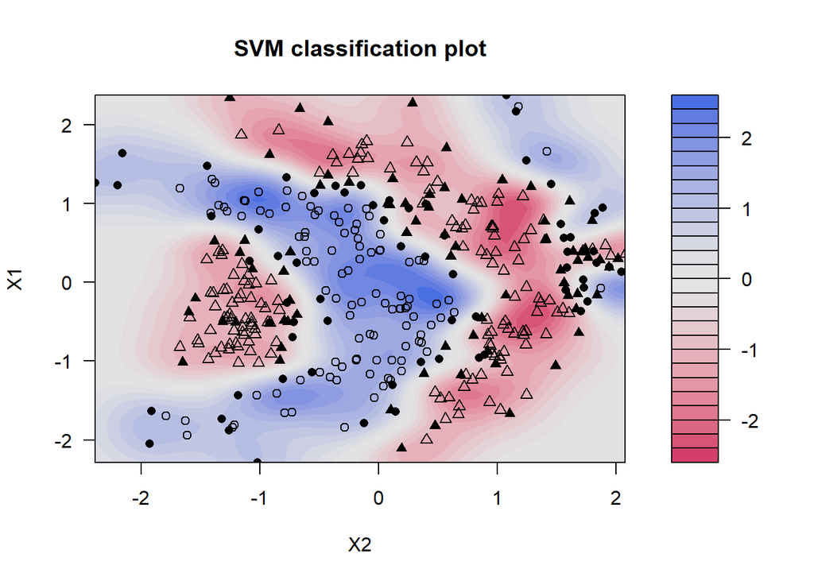

```r
plot(fit.svm1, data = data)
```

En changeant les valeurs de $C$ et $\sigma$, on constate que : Plus $C$ est grand, moins il y aura de vecteurs de support. Plus $sigma$ est grand, plus la frontière est complexe et moins linéaire. L’overfit augmente avec sigma.

## Question 4

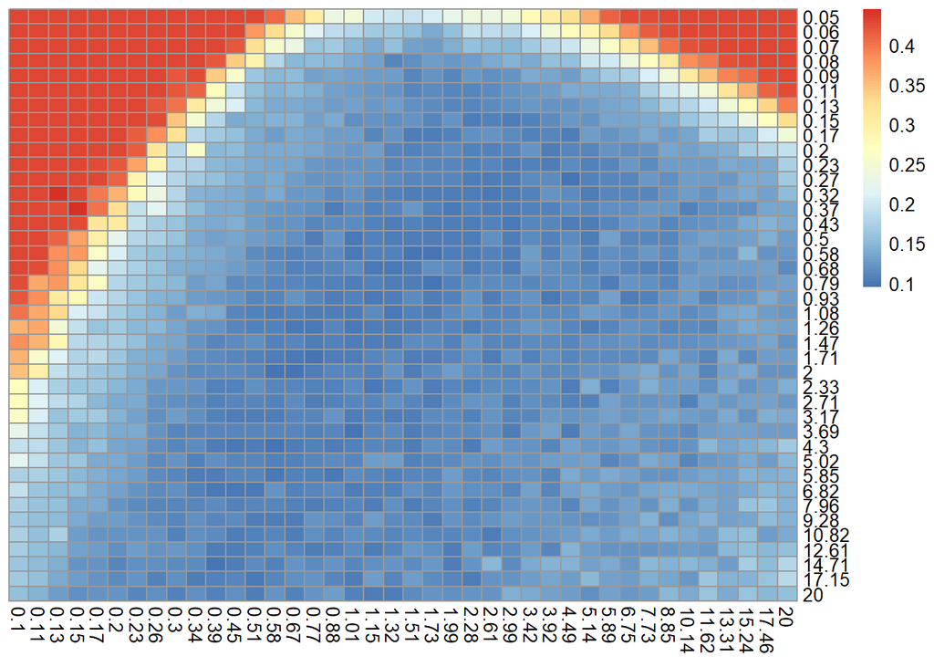

Le couple optimal $(C^*, \sigma^*)$ est
$$C^* = 0.584,\ \sigma^* = 1.514$$

## Question 5

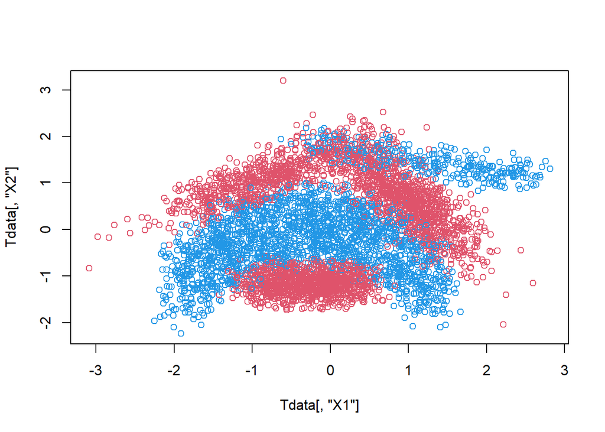

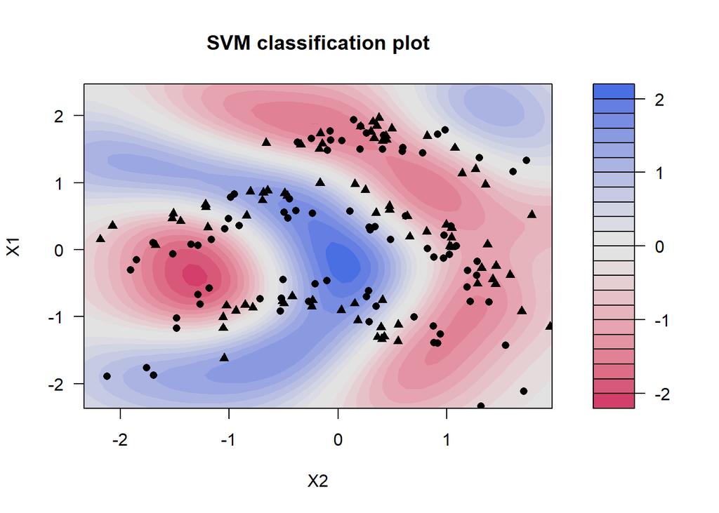

```r
fit.svm3 = ksvm(Y~., data=data, type = 'C-svc', kernal = 'rbfdot', kpar = list(sigma = Sstar), C = Cstar)
error_optim = fit.svm3@error
plot(fit.svm3)
```

```r
error_optim
```

```
## [1] 0.095
```